# Test a Perceptual Phenomenon

## Project: Analyzing the Stroop Effect

**by Ha Phuong Thao (Joanna)**

*This project is a part of the [Data Analyst Nanodegree](https://www.udacity.com/course/data-analyst-nanodegree--nd002?v=a4) program.*

### Background Information

In a Stroop task, participants are presented with a list of words, with each word displayed in a color of ink. The participant’s task is to say out loud the color of the ink in which the word is printed. The task has two conditions: a congruent words condition, and an incongruent words condition. In the congruent words condition, the words being displayed are color words whose names match the colors in which they are printed: for example RED, BLUE. In the incongruent words condition, the words displayed are color words whose names do not match the colors in which they are printed: for example PURPLE, ORANGE. In each case, we measure the time it takes to name the ink colors in equally-sized lists. Each participant will go through and record a time from each condition.

*Dataset provided*: [Stroopdata](https://drive.google.com/file/d/0B9Yf01UaIbUgQXpYb2NhZ29yX1U/view)

```python
import matplotlib.pyplot as plt
import numpy as np
import pandas as pd
from math import *

df = pd.read_csv('stroopdata.csv')
```

## Questions for investigation

### Dependent & Independent variable

*(1) What is the independent variable? What is the dependent variable?*

- Independent variable: "congruent" words condition and "incongruent" words condition
- Dependent variable: the time it takes to name the ink color in equally-size lists

### Hypotheses

*(2) What is an appropriate set of hypotheses for this task? What kind of statistical test do you expect to perform? Justify your choices.*

$$H_{0}: μ_{I} - μ_{C} = 0$$ **Null Hypothesis**: there is no significant difference of average response time in recognizing congruent and incongruent words condition.

$$H_{A}: μ_{I} - μ_{C} != 0$$ **Alternative Hypothesis**: there is a significant difference of average response time for color recognition between congruent and incongruent words condition.

Where $μ_{C}$ and $μ_{I}$ represent average response time of Congruent words condition and Incongruent words condition respectively.

A two-tailed, dependent sample t-test is a proper method to perform. With this test, we seek to determine whether the sample data provided gives enough evidence to reason that the congruent words mean response time is significantly different from the incongruent words mean response time for the entire population. The following points provide the reason why two-tailed dependent sample t-test is appropriate:

- the population variance is unknown
- the sample size is less than 30, which is small, so this data is not appropriate for analysis using normal distribution or z-test. In this case, t distribution allows us to conduct statistical analyses to estimate population parameters.
- the same subject is exposed to two conditions and tested for each, so we focus on the criteria of "within-subject" experiment.

### Descriptive Statistics

*(3) Report some descriptive statistics regarding this dataset. Include at least one measure of central tendency and at least one measure of variability. The name of the data file is 'stroopdata.csv'.*

```python
# Create data series for further investigation
congruent = df['Congruent']
incongruent = df['Incongruent']
```

#### Measure of central tendency

##### Mean

```python
congruent_mean = congruent.mean().round(2)
congruent_mean
```

```
14.05
```

```python
incongruent_mean = incongruent.mean().round(2)
incongruent_mean
```

```
22.02
```

##### Median

```python
congruent_median = round(congruent.median(),2)
congruent_median
```

```
14.36
```

```python
incongruent_median = round(incongruent.median(),2)
incongruent_median
```

```
21.02
```

#### Measure of variability

##### Standard Deviation

```python
congruent_std = congruent.std().round(2)
congruent_std
```

```
3.56
```

```python
incongruent_std = incongruent.std().round(2)
incongruent_std
```

```
4.8
```

| Statistics | Congruent | Incongruent |  |
| --- | --- | --- | --- |
| n | 24 | 24 |  |
| $\bar{x}$ | 14.05 | 22.02 |  |
| median | 14.36 | 21.02 |  |
| std | 3.56 | 4.8 |  |

## Visualizations

*(4) Provide one or two visualizations that show the distribution of the sample data. Write one or two sentences noting what you observe about the plot or plots.*

```
Text(0.5,0,'Time (second)')
```

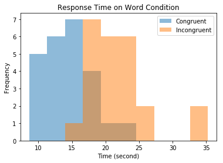

```python
ax = df.plot.hist(alpha=0.5, title = 'Response Time on Word Condition')
ax.set_xlabel('Time (second)')
```

```
Text(0,0.5,'Time (second)')
```

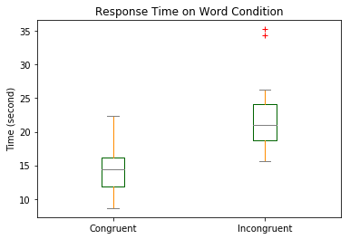

```python
color = dict(boxes = 'DarkGreen', whiskers='DarkOrange', medians='Gray', caps='Gray')
ax = df.plot.box(color=color, sym='r+', title = 'Response Time on Word Condition')
ax.set_ylabel("Time (second)")
```

### Statistical Test

*(5) Now, perform the statistical test and report the results. What is the confidence level and your critical statistic value? Do you reject the null hypothesis or fail to reject it? Come to a conclusion in terms of the experiment task. Did the results match up with your expectations?*

```python
# Sample size
N = len(df)
N
```

```
24
```

```python
# Point estimate
PE = (incongruent_mean - congruent_mean).round(2)
PE
```

```
7.97
```

##### With 99% confidence interval

- $\alpha = 0.01$
- $D_{f} = 23$
- $t_{critical} = + 2.807; - 2.807$

```python
# Standard deviation of Difference
df['Difference'] = df['Incongruent'] - df['Congruent']
std_D = df['Difference'].std()
std_D
```

```
4.864826910359056
```

```python
# t-statistic
t_stat = (PE/(std_D/sqrt(24))).round(3)
t_stat
```

```
8.026
```

##### Result

$t_{statistic} > t_{critical} (8.026 > 2.807)$

#### Conclusion

The calculated t-statistic for the difference in mean response time of words conditions is 8.026. Obviously, t-statistic falls well within the critical region so we reject the null hypothesis. In other words, mean time for color recognition for the congruent data vs. the incongruent data is extremely statistically significant.